# peRidial: Peritonitis Indicators for Peritoneal Dialysis Units

## Overview

peRidial is a standardised R framework for ingesting, validating, and summarising clinical peritoneal dialysis (PD) unit data. Four nested S3 classes represent the PD unit, the cohort of patients in the unit, their catheters, and each catheter’s peritonitis episodes (if any), supporting reproducible calculation of the International Society for Peritoneal Dialysis (ISPD)-recommended PD unit’s peritonitis rate and peritonitis-free percentage indicators from longitudinal catheter and infection records.

This vignette walks through installation and setup, the example data, building a `pd_unit` from PD unit input files, and the `print()`, `summary()`, `plot()` and `subset()` methods for inspecting what was built.

For details on individual pieces, see the other vignettes:

- `vignette("data-structures", package = "peridial")`: how the `pd_unit`, `pd_patient`, `pd_catheter` and `pd_infection` classes fit together.
- `vignette("ispd-indicators-classification", package = "peridial")`: calculating the peritonitis rate and peritonitis-free percentage and and how episodes are classified into relapsing, recurrent and repeat peritonitis.

## Installation and setup

```r
# install.packages("remotes")
remotes::install_github("ernestcaballero/peRidial")
```

> **Note:** peridial includes compiled C++ code (via Rcpp), so installing from source requires a working compiler toolchain: Rtools on Windows, or the Xcode Command Line Tools on macOS (`xcode-select --install`). Linux users typically have a compiler available already.

The package is installed from the `peRidial` repository but loaded under its all-lowercase name:

```r
library(peridial)
```

## The example data

The example uses two synthetic Excel files that ship with the package, covering the 2025 reporting year for a fictional unit:

- `a3_2025.xlsx` is the unit survey called `Form A3` file. Each row is one PD catheter. `Patient ID` identifies the patient and it repeats when a patient has more than one catheter in the period. This input also includes the patient’s demographic details, PD start and stop dates, dialysis modality, and any change of dialysis modality like transplant, permanent transfer to HD or stopped PD. The example file has 62 catheters across 60 patients: 58 patients with a single catheter, and two whose catheter was removed and replaced during the reporting year.
- `pe_2025.xlsx` is the peritonitis episode `Form PE` file. Each row is one peritonitis episode: the date of infection, the organism(s) cultured, the date of the last antibiotic dose, and whether the episode led to hospitalisation, catheter removal or a transfer to haemodialysis. The example file has 28 episodes across 17 patients.

No real patient data is included. The synthetic dataset was modelled on published field definitions: patient- and episode-level data items from the Australia and New Zealand Dialysis and Transplant Registry (ANZDATA) Data Dictionary and its survey `Form A3`, and other catheter-level fields such as procedure type and removal reason from the New Zealand Peritoneal Dialysis Registry (NZPDR), which records them where `Form A3` does not. The column names are the package author’s own, chosen to suit the package, so they match neither an ANZDATA nor an NZPDR export. Values are decoded rather than coded: `Gender` holds `"Female"`, not a registry code. To prepare your own data, see *Using your own data* below.

## Building a `pd_unit`

### Building from the example files

`pd_unit()` reads the two files and builds the whole object in one call. Choose a reporting period with a start date `t0` and an end date `t1`, usually the first and last day of the reporting year. Dates are given in `YYYY-MM-DD` format.

```r
t0 <- as.Date("2025-01-01")
t1 <- as.Date("2025-12-31")

unit <- pd_unit(
  unit_data = system.file("extdata", "a3_2025.xlsx", package = "peridial"),
  infection_data = system.file("extdata", "pe_2025.xlsx", package = "peridial"),
  t0 = t0, t1 = t1, unit_id = "Wellington PD Unit"
)

unit
```

```
#> <pd_unit> Wellington PD Unit
#>   Reporting period      : 2025-01-01 to 2025-12-31
#>   Patients              : 60 (20 incident)
#>   Catheters             : 62
#>   Peritonitis episodes  : 28
#>   Total patient-years   : 48.00
```

Gaps in the source data found while building (for example an episode that cannot be matched to an active catheter, an organism that is not on the accepted list, or a permanent move to haemodialysis recorded without a reason) are collected and raised together as a single error, and **no** unit is built. Correct them in the source files and run `pd_unit()` again until it builds.

An assumption the build can carry on with does not stop it and is reported as an R warning instead. The cases are a transplant or a permanent move to haemodialysis that is recorded without a date, and a column name that could match more than one expected column. For a missing date, the warning says what the build did in its place: the patient is treated as still on PD, or, if another event or a closed catheter already ended their PD, censored on that date. Warnings are only shown once there are no errors, so a build that fails reports the errors first and the warnings appear when it succeeds.

### Using your own data

> **Important:** the column names in the synthetic dataset were chosen by the package author, so an ANZDATA or NZPDR export will not match them exactly. Some differing names are recognised automatically (see below), but a raw export will usually need renaming before it loads.

To use your own data:

1. Load it into R, for example with `readr::read_csv()` or `readxl::read_excel()`.
2. Select the columns whose meaning most closely matches the columns in the table below.
3. Rename them to match, and recode values where needed (for example, coded values to plain ones such as `"Female"`).
4. Pass the cleaned tables to `pd_unit()`. `unit_data` and `infection_data` each accept a data frame already in R, or the path to an `.xlsx` or `.csv` file, so cleaned data held in R does not need to be written out first.

Your files must use the column names in the table below. Capitalisation, spacing and punctuation are ignored, so `Patient ID`, `patient_id` and `PatientID` are all read as the same column. Beyond that, `pd_unit()` matches on keywords, so a name that differs but still carries the expected words is picked up. For example,`Infection Date` is read as `Date of Infection`, `DOB` as `Date of Birth`, and `Sex` as `Gender`. A column already named exactly as the target always keeps that role and is never reassigned. Where no such column exists and two or more columns could both match one target, the leftmost one in the file is used, the build carries on, and a warning names the candidates and the column that is chosen.

[output not shown]

A missing required column stops the build with an error that lists what was found. Check the spelling of optional columns carefully as a missing optional column is filled with `NA` without a warning. An incorrect `Date of Death` or `PD Stop Date` name column, for example, means patients are not censored and patient-years are overstated.

Values should follow these formats:

- `Patient ID` must be in NHI format: three letters then four digits (`ABC1234`), case-insensitive. A row whose ID is a different shape is reported and the build stops.
- Dates can be Excel date cells, `Date` columns, or text in `YYYY-MM-DD` or day-first format (`31/01/2025`, `31-01-2025`). A date that cannot be read is set to `NA` with a warning.
- A `.csv` file is read as it is: column names are standardised as for Excel files, and blank cells and `NA` are missing values.
- Yes/no columns accept `Yes`/`No`, `Y`/`N`, `TRUE`/`FALSE` or `1`/`0`.
- Several organisms for one episode go in one cell, separated by commas.
- A permanent move to haemodialysis is recorded as `Any PD to HD` in Dialysis Modality Change.

The outline below shows steps 1 to 4. The column names on the right-hand side of each assignment, and the recoding, are placeholders to replace with your own.

```r
raw_a3 <- readxl::read_excel("my_unit_export.xlsx")
raw_pe <- readxl::read_excel("my_peritonitis_export.xlsx")

a3 <- data.frame(
  "Patient ID" = raw_a3$MRN,
  "Date of Birth" = raw_a3$DOB,
  "Insertion Date" = raw_a3$CatheterInsertDate,
  "PD Start Date" = raw_a3$PDStart,
  "Gender" = ifelse(raw_a3$Sex == 1, "Male", "Female"),  # recode
  check.names = FALSE
)

pe <- data.frame(
  "Patient ID"  = raw_pe$MRN,
  "Date of Infection" = raw_pe$InfectionDate,
  "Organism" = raw_pe$Organism,
  check.names = FALSE
)

unit <- pd_unit(
  unit_data = a3,
  infection_data = pe,
  t0 = as.Date("2025-01-01"),
  t1 = as.Date("2025-12-31"),
  unit_id = "Your PD Unit"
)
```

## Inspecting a unit

Four S3 methods do the work of looking at what was built. `print()` is defined for every class, `summary()` for a unit and a patient, `plot()` for a unit, and `subset()` for a unit, a patient or a catheter.

| Method | `pd_unit` | `pd_patient` | `pd_catheter` | `pd_infection` |
| --- | --- | --- | --- | --- |
| `print()` | yes | yes | yes | yes |
| `summary()` | yes | yes | – | – |
| `plot()` | yes | – | – | – |
| `subset()` | yes | yes | yes | – |

### `print()`

`print()` gives a short, fixed set of fields for one object; printing `unit` above used it. Because the same method is defined at each level, an object can be printed wherever it sits in the hierarchy. The nested objects are reachable through the unit’s `patient_list`:

```r
pat <- Filter(function(p) p$patient_id == "SPD0059", unit$patient_list)[[1]]
pat
```

```
#> <pd_patient> SPD0059
#>   Reporting window     : 2025-01-01 to 2025-12-31
#>   Status               : prevalent
#>   Catheters            : 2
#>   Peritonitis          : 0
#>   Censoring          : permanent transfer to HD on 2025-09-18
```

This patient’s first catheter was removed and replaced during the year, so they have two, and they left PD before the period ended. Printing the second catheter shows its own window and why it was removed:

```r
pat$catheters[[2]]
```

```
#> <pd_catheter> SPD0059
#>   Reporting window   : 2025-01-01 to 2025-12-31
#>   Catheter           : SPD0059_02
#>   Inserted           : 2025-04-22
#>   Procedure type     : Laparoscopic
#>   PD window          : 2025-05-06 to 2025-09-18 (removed, Catheter Block)
#>   Peritonitis        : 0
```

A `pd_infection` prints its organisms, its episode type and its outcome. An `NA` in outcome means resolved peritonitis case, not missing:

```r
spd0003 <- Filter(function(p) p$patient_id == "SPD0003", unit$patient_list)[[1]]
spd0003$catheters[[1]]$infections[[2]]
```

```
#> <pd_infection> SPD0003
#>   Infection date       : 2025-03-15
#>   Organism/s           : S. epidermidis
#>   Episode type         : relapsing
#>   Last dose antibiotic : 2025-03-29
#>   Outcome              : NA
```

### `summary()`

`summary()` on a unit prints the indicator report: the peritonitis rate and the peritonitis-free percentage with their numerators and denominators, each judged against the benchmark carried on the object (`[ MET ]` or `[ NOT MET ]`), then episodes by type, how patients left PD, demographics, catheters and organisms.

```r
s <- summary(unit)
```

```
#> <summary.pd_unit>  Wellington PD Unit
#> Reporting period   2025-01-01 to 2025-12-31
#> ════════════════════════════════════════════════════════
#>
#>  PERITONITIS RATE
#>    Rate                            0.521 episodes/patient-year
#>    Countable episodes              25
#>    Patient-years at risk           48.00
#>    ISPD benchmark                  <= 0.40        [ NOT MET ]
#>
#>  PERITONITIS-FREE (PF)
#>    PF                              71.7%
#>    Patients, zero countable eps    43 of 60
#>    ISPD benchmark                  > 80%          [ NOT MET ]
#>
#>  EPISODES BY TYPE
#>    recurrent                       4
#>    relapsing                       3
#>    repeat                          2
#>    uncategorised                   19
#>
#>  COHORT OUTCOMES
#>    death                           3
#>    permanent transfer to HD        6
#>    still active                    48
#>    transplant                      3
#>
#>  DEMOGRAPHICS
#>    Mean age                        53 (at t1)
#>    Gender                          Female 25, Male 35
#>    Ethnicity                       Asian 8, Maori 16, NZ European 19, Other 1, Pacific Islander 16
#>    Kidney disease                  Diabetic nephropathy 18, Glomerulonephritis 13, Hypertensive nephropathy 10, IgA nephropathy 9, Polycystic kidney disease 5, Reflux nephropathy 5
#>    Diabetes                        None 20, Type 1 3, Type 2 37
#>    Smoking status                  Current 10, Ex-smoker 22, Never 28
#>    Dialysis type                   APD 29, CAPD 31
#>
#>  CATHETERS
#>    Total                           62
#>    Procedure type                  Laparoscopic 19, Percutaneous 2, Surgical 41
#>    Time to PD start (mean)         14.7 days
#>    Time to 1st peritonitis (mean)  119.7 days
#>
#>  INFECTIONS
#>    Organisms cultured              E. coli 5, Enterococcus 2, Klebsiella 3, negative 3, P. aeruginosa 3, S. aureus 5, S. epidermidis 7
#>    PE outcome                      hospitalisation 7, none 20, temporary transfer to HD 1
#>    Culture-negative peritonitis    3 (10.7%)
#>    Peritonitis catheter removal    0 (0.0%)
#>
#>  COHORT
#>    Patients                        60 (20 incident, 40 prevalent)
```

It also returns those components invisibly, so they can be used directly:

```r
s$rate
```

```
#> [1] 0.520863
```

```r
s$rate_met
```

```
#> [1] FALSE
```

```r
s$episode_types
```

```
#> types
#>     recurrent     relapsing        repeat uncategorised
#>             4             3             2            19
```

`summary()` on a single patient is the same idea one level down: their status, age, demographics, each catheter’s window and outcome, their total time at risk, and their countable episodes by type.

```r
summary(spd0003)
```

```
#> <summary.pd_patient> SPD0003
#>   Reporting window   : 2025-01-01 to 2025-12-31
#>   Status             : prevalent
#>   Age                : 56 (at t1)
#>   Gender             : Male
#>   Ethnicity          : NZ European
#>   Kidney disease     : Diabetic nephropathy
#>   Diabetes           : Type 2
#>   Smoking status     : Ex-smoker
#>   Dialysis type      : APD
#>   Catheters (1)      :
#>     SPD0003_01 : inserted 2020-10-21, PD 2020-11-10 to (active)
#>         - 2025-02-10 : S. epidermidis
#>   Total exposure     : 365 days (1.00 patient-years)
#>   Peritonitis history: 1 countable episode (1 uncategorised)
```

### `plot()`

`plot()` draws the unit’s indicators. `type = "monthly"` and `type = "quarterly"` bin the reporting period into calendar months or quarters and plot the rate in each, with the benchmark as a reference line:

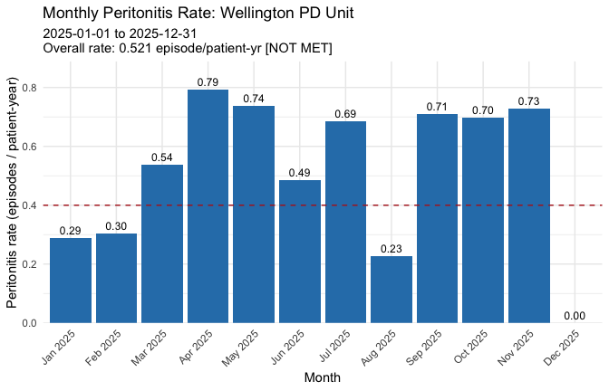

```r
plot(unit, type = "monthly")
```

`type = "yearly"` instead plots the cumulative, year-to-date rate and peritonitis-free percentage as two panels, so both indicators can be read against their benchmarks over the same period:

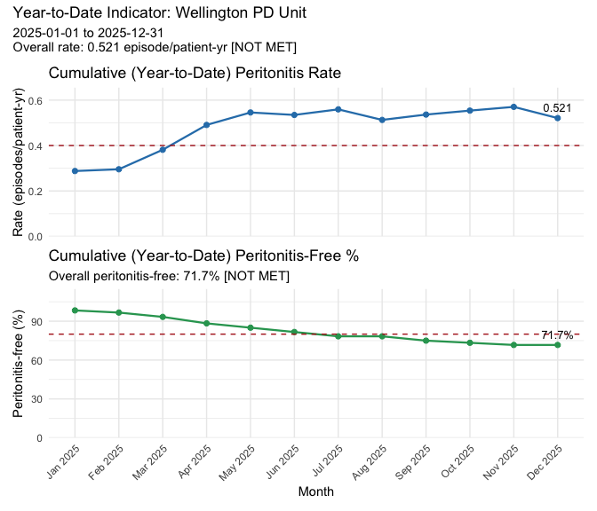

```r
plot(unit, type = "yearly")
```

`plot()` needs ggplot2, and `type = "yearly"` also needs patchwork; both are suggested packages rather than hard dependencies. The reference line defaults to the unit’s own `rate_benchmark` and can be overridden for one plot with `benchmark`. With `type = "yearly"`, four optional cohort panels can be added underneath, each off by default:

```r
plot(unit, type = "yearly", benchmark = 0.50,
     show_ip = TRUE,            # incident vs prevalent
     show_pkd = TRUE,           # primary kidney disease
     show_modality = TRUE,      # CAPD / APD / hybrid
     show_stop.reason = TRUE)   # why catheters were stopped
```

### `subset()`

`subset()` asks questions about the data of interest by using filters and conditions. It joins the unit’s `patients`, `catheters` and `infections` tibbles into one flat table, one row per episode carrying its catheter’s and its patient’s columns, and returns the rows that meet a condition as a plain tibble:

```r
subset(unit, episode_type == "recurrent",
       select = c(patient_id, catheter_id, infection_date, organisms, episode_type))
```

```
#> # A tibble: 4 × 5
#>   patient_id catheter_id infection_date organisms     episode_type
#>   <chr>      <chr>       <date>         <chr>         <chr>
#> 1 SPD0023    SPD0023_01  2025-05-06     E. coli       recurrent
#> 2 SPD0030    SPD0030_01  2025-10-20     P. aeruginosa recurrent
#> 3 SPD0046    SPD0046_01  2025-10-15     P. aeruginosa recurrent
#> 4 SPD0047    SPD0047_01  2025-11-10     E. coli       recurrent
```

`subset` and `select` are written as in base `subset()`: a logical condition on any column of the flat table, and column names, ranges (`patient_id:gender`) or negation (`-t0`). `NA` counts as `FALSE`, so a condition on an episode column keeps only the rows that have an episode.

A patient with no episodes still has a row, with the episode columns `NA`, and a patient with several catheters or episodes has several rows, so row counts are not patient counts:

```r
nrow(subset(unit))
```

```
#> [1] 73
```

```r
nrow(subset(unit, !is.na(infection_date)))
```

```
#> [1] 28
```

```r
dplyr::n_distinct(subset(unit)$patient_id)
```

```
#> [1] 60
```

Using `subset`, the indicators are not recalculated and the unit is not modified: the result is a tibble to inspect, not a smaller `pd_unit`. The same method is defined for a patient and for a catheter, over whatever sits below them:

```r
subset(pat, select = c(catheter_id, pd_start_date, pd_stop_date, removal_reason))
```

```
#> # A tibble: 2 × 4
#>   catheter_id pd_start_date pd_stop_date removal_reason
#>   <chr>       <date>        <date>       <chr>
#> 1 SPD0059_01  2024-02-08    2025-04-10   Unable to Manage Self-Care
#> 2 SPD0059_02  2025-05-06    2025-09-18   Catheter Block
```